# My Project New

Debanjan Borthakur

November 22, 2015

Final Project Debanjan Borthakur 22/11/2015

```r
library(caret)
```

```r
library(rpart)
library(rpart.plot)
library(RColorBrewer)
library(rattle)
library(randomForest)
library(knitr)
library(ggplot2)
library(MASS)
library(lattice)
```

# Project Introduction

## Background

Using devices such as Jawbone Up, Nike FuelBand, and Fitbit it is now possible to collect a large amount of data about personal activity relatively inexpensively. These type of devices are part of the quantified self movement - a group of enthusiasts who take measurements about themselves regularly to improve their health, to find patterns in their behavior, or because they are tech geeks. One thing that people regularly do is quantify how much of a particular activity they do, but they rarely quantify how well they do it. In this project, your goal will be to use data from accelerometers on the belt, forearm, arm, and dumbell of 6 participants. They were asked to perform barbell lifts correctly and incorrectly in 5 different ways. More information is available from the website here: http://groupware.les.inf.puc-rio.br/har (see the section on the Weight Lifting Exercise Dataset).

## Data

The training data for this project are available here: https://d396qusza40orc.cloudfront.net/predmachlearn/pml-training.csv

The test data are available here: https://d396qusza40orc.cloudfront.net/predmachlearn/pml-testing.csv

The data for this project come from this source: http://groupware.les.inf.puc-rio.br/har. If you use the document you create for this class for any purpose please cite them as they have been very generous in allowing their data to be used for this kind of assignment.

## Goal

```r
set.seed(12345)

trainUrl <- "http://d396qusza40orc.cloudfront.net/predmachlearn/pml-training.csv"
testUrl <- "http://d396qusza40orc.cloudfront.net/predmachlearn/pml-testing.csv"

training <- read.csv(url(trainUrl), na.strings=c("NA","#DIV/0!",""))
testing <- read.csv(url(testUrl), na.strings=c("NA","#DIV/0!",""))
```

## Partioning the training set into two

```r
inTrain <- createDataPartition(training$classe, p=0.6, list=FALSE)
Training <- training[inTrain, ]
Testing <- training[-inTrain, ]
dim(Training); dim(Testing)
```

```
## [1] 11776   160
```

```
## [1] 7846  160
```

## Cleaning the data

```r
Datanzv <- nearZeroVar(Training, saveMetrics=TRUE)
Training <- Training[,Datanzv$nzv==FALSE]
Datanzv<- nearZeroVar(Testing,saveMetrics=TRUE)
Testing <- Testing[,Datanzv$nzv==FALSE]
```

## Remove the first column of the Training data set

```r
Training <- Training[c(-1)]
```

```r
trainingB12 <- Training
for(i in 1:length(Training)) {
    if( sum( is.na( Training[, i] ) ) /nrow(Training) >= .6) {
        for(j in 1:length(trainingB12)) {
            if( length( grep(names(Training[i]), names(trainingB12)[j]) ) == 1)  {
                trainingB12 <- trainingB12[ , -j]
            }
        }
    }
}
```

## Back to the original variable name

```r
Training <- trainingB12
rm(trainingB12)
```

## Transform the Testing and testing data sets

```r
cl1 <- colnames(Training)
cl2 <- colnames(Training[, -58])
Testing <- Testing[cl1]
testing <- testing[cl2]
dim(Testing)
```

```
## [1] 7846   58
```

## Coerce the data

```r
for (i in 1:length(testing) ) {
    for(j in 1:length(Training)) {
        if( length( grep(names(Training[i]), names(testing)[j]) ) == 1)  {
            class(testing[j]) <- class(Training[i])
        }
    }
}
```

## To get the same class between testing and Training

```r
testing <- rbind(Training[2, -58] , testing)
testing <- testing[-1,]
```

## Prediction with LDA

```r
set.seed(12345)
modelFit <- train(classe ~ .,data=Training, method="lda")
predictions <- predict(modelFit,newdata=Testing)
confusionMatrix(predictions,Testing$classe)
```

```
## Confusion Matrix and Statistics
##
##           Reference
## Prediction    A    B    C    D    E
##          A 2025  162    3    0    0
##          B  183 1112  120    1    0
##          C   24  234 1212  135    3
##          D    0   10   31 1076  135
##          E    0    0    2   74 1304
##
## Overall Statistics
##
##                Accuracy : 0.8576
##                  95% CI : (0.8497, 0.8653)
##     No Information Rate : 0.2845
##     P-Value [Acc > NIR] : < 2.2e-16
##
##                   Kappa : 0.8201
##  Mcnemar's Test P-Value : NA
##
## Statistics by Class:
##
##                      Class: A Class: B Class: C Class: D Class: E
## Sensitivity            0.9073   0.7325   0.8860   0.8367   0.9043
## Specificity            0.9706   0.9520   0.9389   0.9732   0.9881
## Pos Pred Value         0.9247   0.7853   0.7537   0.8594   0.9449
## Neg Pred Value         0.9634   0.9369   0.9750   0.9682   0.9787
## Prevalence             0.2845   0.1935   0.1744   0.1639   0.1838
## Detection Rate         0.2581   0.1417   0.1545   0.1371   0.1662
## Detection Prevalence   0.2791   0.1805   0.2049   0.1596   0.1759
## Balanced Accuracy      0.9389   0.8423   0.9124   0.9049   0.9462
```

## Prediction with Random Forests

```r
set.seed(12345)
modFit1 <- randomForest(classe ~ ., data=Training)
prediction1 <- predict(modFit1, Testing, type = "class")
rf <- confusionMatrix(prediction1, Testing$classe)
rf
```

```
## Confusion Matrix and Statistics
##
##           Reference
## Prediction    A    B    C    D    E
##          A 2231    2    0    0    0
##          B    1 1516    0    0    0
##          C    0    0 1367    3    0
##          D    0    0    1 1282    1
##          E    0    0    0    1 1441
##
## Overall Statistics
##
##                Accuracy : 0.9989
##                  95% CI : (0.9978, 0.9995)
##     No Information Rate : 0.2845
##     P-Value [Acc > NIR] : < 2.2e-16
##
##                   Kappa : 0.9985
##  Mcnemar's Test P-Value : NA
##
## Statistics by Class:
##
##                      Class: A Class: B Class: C Class: D Class: E
## Sensitivity            0.9996   0.9987   0.9993   0.9969   0.9993
## Specificity            0.9996   0.9998   0.9995   0.9997   0.9998
## Pos Pred Value         0.9991   0.9993   0.9978   0.9984   0.9993
## Neg Pred Value         0.9998   0.9997   0.9998   0.9994   0.9998
## Prevalence             0.2845   0.1935   0.1744   0.1639   0.1838
## Detection Rate         0.2843   0.1932   0.1742   0.1634   0.1837
## Detection Prevalence   0.2846   0.1933   0.1746   0.1637   0.1838
## Balanced Accuracy      0.9996   0.9993   0.9994   0.9983   0.9996
```

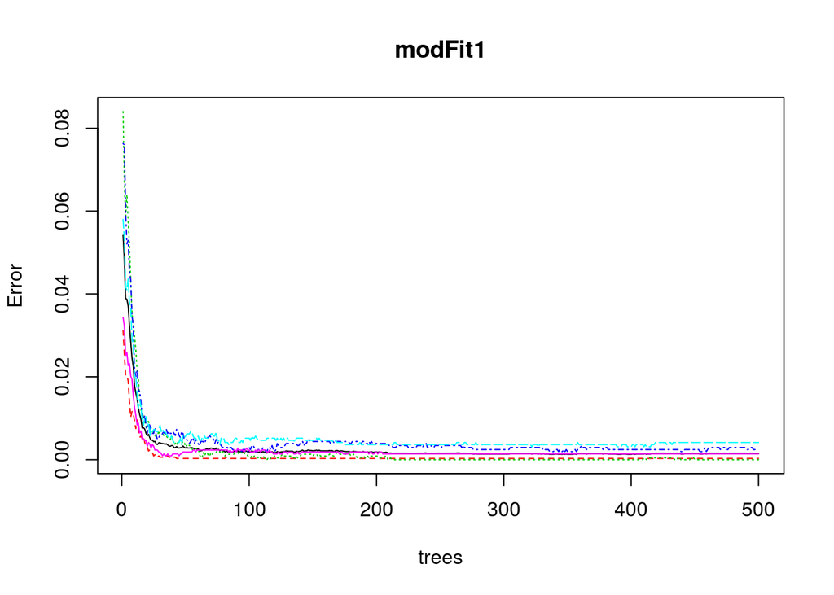

```r
plot(modFit1)
```

## Predicting Results on the Test Data

Random Forests gave an Accuracy in the Test dataset of 99.89%, which was more accurate than what we see in Linear Discriminent Analysis. The expected out-of-sample error is 100-99.89 = 0.11%.

```r
prediction1 <- predict(modFit1, testing, type = "class")
prediction1
```

```
##  2 31  4  5  6  7  8  9 10 11 12 13 14 15 16 17 18 19 20 21
##  B  A  B  A  A  E  D  B  A  A  B  C  B  A  E  E  A  B  B  B
## Levels: A B C D E
```

## Write results

```r
pml_write_files = function(x){
  n = length(x)
  for(i in 1:n){
    filename = paste0("problem_id_",i,".txt")
    write.table(x[i],file=filename,quote=FALSE,row.names=FALSE,col.names=FALSE)
  }
}
pml_write_files(prediction1)
```